# CQF Exam One

#### June 2022 Cohort

## Summary Tables

### A

**1 (a)** : $\$\,$1.798

**1 (b)** : If the forward price of yen increases during the two months(July and August of 2009), this strategy will make a profit of the forward price difference.

**1 (c)** : $\$\,$8.907

**2** : $\$$ 0.75 (present value)

**3 (a)** : results in code and plot

**3 (b)** : results in code and plot

### B

**1** : $$ \pmb{\Sigma} = \begin{pmatrix} 0.0049 & 0.00168& 0.0063 & 0.00546\\ 0.00168& 0.0144 & 0.01512& 0.01248\\ 0.0063 & 0.01512& 0.0324 & 0.04212\\ 0.00546& 0.01248& 0.04212& 0.0676\\ \end{pmatrix} $$

**2** :

- The optimization is to find the weights of the assets in a portfolio which has the minimum variance/risk possible while giving the average return of 10% ( 𝜔𝑇𝜔𝑇𝜇𝜇=0.1 ) at the same time.
- $$ \pmb{\omega^*} = \begin{pmatrix} 0.05867697\\ 0.75902696\\ -0.31954512\\ 0.50184119\\ \end{pmatrix} $$
- $\sigma_{\pi}$ = 0.13245841
- see the plot

**3** :

- The optimization is to find the weights of the assets in a portfolio which has the least variance/risk possible.
- $$ \pmb{\omega^*} = \begin{pmatrix} 0.90541287\\ 0.82908361\\ -1.37463819\\ 0.64014171\\ \end{pmatrix} $$
- $\mu_{\pi}$ = 0.03360788, $\sigma_{\pi}$ = 0.02577473
- see the plot and the optimal portfolio is named as "The Global Minimum Variance Portfolio"

### C

**1** : see the code and the excel file result

**2** : see the code and the excel file result

**3** :

The percentage of breaches for sample standard deviation measure is 2.7607361963190185%.

The percentage of breaches for GARCH measure is 2.2044088176352705%.

- The VaR breach is not an i.i.d process.
- The VaR breaches are not independent of time.
- The VaR breaches are not independent of the level of VaR (volatility).

## A. Products, Strategies and Pricing

### Question 1

**(a)**

Consider a portfolio: long one put option, long an amount $\Delta$ of the stock(the asset of the put option). Denote V to be the value of the put option, the portfolio value at current time is: V + 80$\Delta$; at the end of four months, the portfolio value will be either 5 + 75$\Delta$ if the stock price falls to $\$$75, or 85$\Delta$ if the stock price rises to $\$$85.

According to delta hedge: $$ 5 + 75\Delta = 85\Delta $$ thus $\Delta = 0.5$. According to the No Arbitrage Principle: $$ V + 80\Delta = discount factor \times 85\Delta $$ and the discount factor = $ e^{-\frac{4}{12} \times 0.05} $, so: $$ V = e^{-\frac{1}{3} \times 0.05} \times 42.5 - 40 = 1.798 $$ The value of a four month European put option with strike $\$\,$80 is $\$\,$1.798.

**(b)**

Suppose that the currency to buy and sell Yen in the two forward contracts remains the same, so that:

- $P_L$: the forward price of delivery of 1 unit of Japanese Yen in the buying forward contract entered on July 1, 2009
- $P_S$: the forward price of delivery of 1 unit of Japanese Yen in the selling forward contract entered on September 1, 2009
- $P$: the price of 1 unit of Japanese Yen on January 1, 2010

The buying forward contract has the profit of $ 10\, million \times (P - P_L) $ on January 1, 2010;

The selling forward contract has the profit of $ 10\, million \times (P_S - P) $ on January 1, 2010;

Together, the payoff (in profit form) is: $$ 10\, million \times (P - P_L) + 10\, million \times (P_S - P) = 10\, million \times (P_S - P_L) $$ So if the forward price of yen increases during the two months(July and August of 2009), this strategy will make a profit of $(P_S - P_L)$ per Yen; otherwise, the strategy will make a loss of $(P_L - P_S)$ per Yen.

Futhurmore, if the forward price is a linear function of the exchange rate, then the payoff is a function of the difference of the exchange rate.

**(c)**

The discount factor quarterly is $ e^{r \times \frac{1}{4}} = e^{0.1 \times \frac{1}{4}} $

At the current time, the value of holding one ounce of silver is: $$ 8 + \frac{0.36}{4} = \$ \, 8.09 $$

At the beginning of the 4th month, the value of holding one ounce of silver is: $$ 8.09 \times e^{0.1 \times \frac{1}{4}} + \frac{0.36}{4} = \$\, 8.385 $$

At the beginning of the 7th month, the value of holding one ounce of silver is: $$ 8.385 \times e^{0.1 \times \frac{1}{4}} + \frac{0.36}{4} = \$\, 8.687 $$

At the end of the 9th month, the value of holding one ounce of silver is: $$ 8.687 \times e^{0.1 \times \frac{1}{4}} = \$\, 8.907 $$

The future price of silver for delivery in 9 months is $\$\,$8.907.

### Question 2

First, check whether there is any arbitrage opportunity. Suppose there is a call option with the same underlying, the same time to expiry and the same strick price. The price of the call option is denoted as C. According to the Put-Call Parity: $$ C + E \times discount factor = P + S $$ $$ C = 4 + 95 - 100 \times e^{-0.03 \times \frac{1}{12}} = \$\,-0.75$$ As the price of any call option cannot be negative, it's obvious that the arbitrage opportunity exists (the put option is under-priced).

Consider a portfilio of: long a put option and long a underlying. The current value of the portfolio is $4+95=\$\,99$. At the expiry date, if the underlying price is less than $\$\,$100, excute the put option to get $\$\,$100; if the underlying price is not less than $\$\,$100, sell the underlying to get at least $\$\,$100. So the value of the portfolio at the expiry date is at least $\$\,$100, which equals to $100 \times discount factor = \$\, 99.75$ current value.

So the minimun profit of my arbitrage portfilio is $\$$ 0.75 (present value).

### Question 3

**Corresponding code in WANG_CODE.ipynb A.3**

**（a）**

With fixed value of stock price S = 100, interest rate r = 0.05 (continuously compounded), strike price E = 100, maturity T = 1 and number of time steps of the tree NTS = 4, here is the plot of the call option value with respect to the different volatilities.

Here I used the Cox-Ross-Rubinstein implementation of the binomial model for illustration.

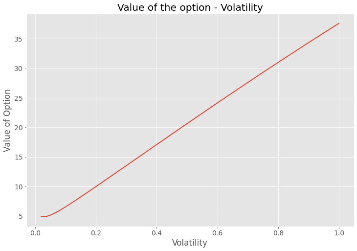

**(b)**

With fixed value of stock price S = 100, interest rate r = 0.05 (continuously compounded), strike price E = 100, maturity T = 1 and volatility $\sigma = 0.2$, here is the plot of the call option value with respect to the different numbers of time steps of the tree in Binomial Tree Model.

Here I used the number of steps of range from 4 to 199 using 196 data points. From the plot, there is a tendency that the output value of the binomial tree model converges to a certain value as the number of steps increases. Depending on the oddness and evenness of the number of steps, the option value will be above and below the convergence value respectively.

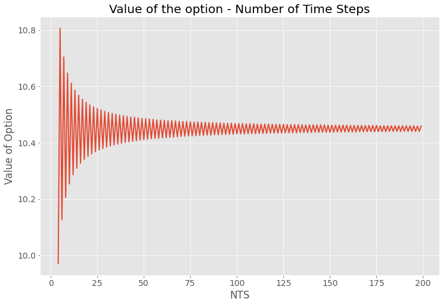

## B. Portfolio Optimisation

### Question 1

**Corresponding code in WANG_CODE.ipynb B.1**

- the colunm vector of the asset weight $\pmb{\omega}$, $\pmb{\omega}^T = (\omega_A \; \omega_B \; \omega_C \; \omega_D)$
- the colunm vector of the asset return $\pmb{\mu}$, $\pmb{\mu}^T = (0.04 \; 0.08 \; 0.12 \; 0.15)$
- the standard deviation matrix of the assets $\pmb{\sigma}$, $ \pmb{\sigma} = \begin{pmatrix} 0.07&0&0&0\\ 0&0.12&0&0\\ 0&0&0.18&0\\ 0&0&0&0.26\\ \end{pmatrix} $
- the correlation matrix of the assets $\pmb{R}$, $ \pmb{R} = \begin{pmatrix} 1&0.2&0.5&0.3\\ 0.2&1&0.7&0.4\\ 0.5&0.7&1&0.9\\ 0.3&0.4&0.9&1\\ \end{pmatrix} $

The covariance matrix: $$ \pmb{\Sigma} = \pmb{\sigma^T}\pmb{R}\pmb{\sigma} = \begin{pmatrix} 0.0049 & 0.00168& 0.0063 & 0.00546\\ 0.00168& 0.0144 & 0.01512& 0.01248\\ 0.0063 & 0.01512& 0.0324 & 0.04212\\ 0.00546& 0.01248& 0.04212& 0.0676\\ \end{pmatrix} $$

### Question 2

**Corresponding code in WANG_CODE.ipynb B.2**

- **Explain in plain English what this optimization does:**

Given a portfolio composed of Asset A, Asset B, Asset C and Asset D only ($\pmb{\omega^T}\pmb{1} = 1$). The optimization is to find the weights of the assets in a portfolio which has the minimum variance/risk possible while giving the average return of 10% ($\pmb{\omega^T}\pmb{\mu} = 0.1$) at the same time.

- **Solve this optimization using the Lagrangian method:**

Suppose m denotes the return of the portfolio, here m = 0.1.

Form the Lagrange function with two lagrange multipliers $\lambda$ and $\gamma$:

$$ L(\pmb{\omega}, \lambda, \gamma) = \frac{1}{2}\pmb{\omega^T}\pmb{\Sigma}\pmb{\omega} + \lambda(m-\pmb{\omega^T}\pmb{\mu}) + \gamma(1-\pmb{\omega^T}\pmb{1})$$

Solve for the first order condition:

$$ \frac{\partial L}{\partial \pmb{\omega}}(\pmb{\omega}, \lambda, \gamma) = \pmb{\Sigma}\pmb{\omega} - \lambda\pmb{\mu} - \gamma\pmb{1} = 0 $$$$ \frac{\partial L}{\partial \lambda}(\pmb{\omega}, \lambda, \gamma) = m-\pmb{\omega^T}\pmb{\mu} = 0 $$$$ \frac{\partial L}{\partial \gamma}(\pmb{\omega}, \lambda, \gamma) = 1-\pmb{\omega^T}\pmb{1} = 0 $$

Then, the candidate $\pmb{\omega^*}$ is:

$$ \pmb{\omega^*} = \pmb{\Sigma^{-1}}(\lambda\pmb{\mu} + \gamma\pmb{1}) $$

where:

$$ \lambda = \frac{Am-B}{AC-B^2} $$$$ \gamma = \frac{C-Bm}{AC-B^2} $$$$ \left\{ \begin{matrix} A = \pmb{1}^T\pmb{\Sigma^{-1}}\pmb{1} \\ B = \pmb{\mu}^T\pmb{\Sigma^{-1}}\pmb{1}\\ C = \pmb{\mu}^T\pmb{\Sigma^{-1}}\pmb{\mu} \end{matrix} \right. $$

Check with the second order condition:

$$ \frac{\partial^2 L}{\partial \pmb{\omega^2}}(\pmb{\omega}, \lambda, \gamma) = \pmb{\Sigma} > 0 $$

(Because $\pmb{\Sigma}$ is the covariance matrix, which means it is positive definite here.) So the $\pmb{\omega^*}$ gives the minimun value of $\frac{1}{2}\pmb{\omega^T}\pmb{\Sigma}\pmb{\omega}$:

$$ \pmb{\omega^*} = \frac{1}{AC-B^2}\pmb{\Sigma^{-1}}[(A\pmb{\mu}-B\pmb{1})m + (C\pmb{1} - B\pmb{\mu})] $$

Taking the number into the calculation, the results are:

$$ \left\{ \begin{matrix} A\approx 1505.26087512\\ B\approx 50.58862248\\ C\approx 1.96129471 \end{matrix} \right. $$$$ \left\{ \begin{matrix} \lambda \approx 0.25426051\\ \gamma \approx -0.0078808\\ \end{matrix} \right. $$$$ \pmb{\omega^*} = \begin{pmatrix} 0.05867697\\ 0.75902696\\ -0.31954512\\ 0.50184119\\ \end{pmatrix} $$

- **Compute the standard deviation of this optimal portfolio:**

The standard deviation of a portfolio can be expressed as:

$$ \sigma_{\pi} = \sqrt{\pmb{\omega^T}\pmb{\Sigma}\pmb{\omega}} $$

Substitute the $\pmb{\omega^*}$ and $\pmb{\Sigma}$ in, the result is $\sigma_{\pi}$ = 0.13245841.

- **On a graph of expected returns plotted against standard deviation, identify this optimal portfolio:**

This plot consists of 10,000 simulated portfolio data points, the weights are chosen randomly and sum to 1. To give a more general expected return - standard deviation plot, the weights are set to be possibly negative (leveraged condition) as well. The simulated portfolio data points are plotted in semi-transparent blue circle-dot. The black crosses represent the four assets. The red star represent the optimal portfolio obtained above, with the expected return of 10% and the standard deviation of 13.246%. Because this is the optimal portfolio of 10% return (which means among all portfolios with 10% of expected return, it has the lowest variance/standard deviation), it is the left-most data point given expected return of 10 in the plot.

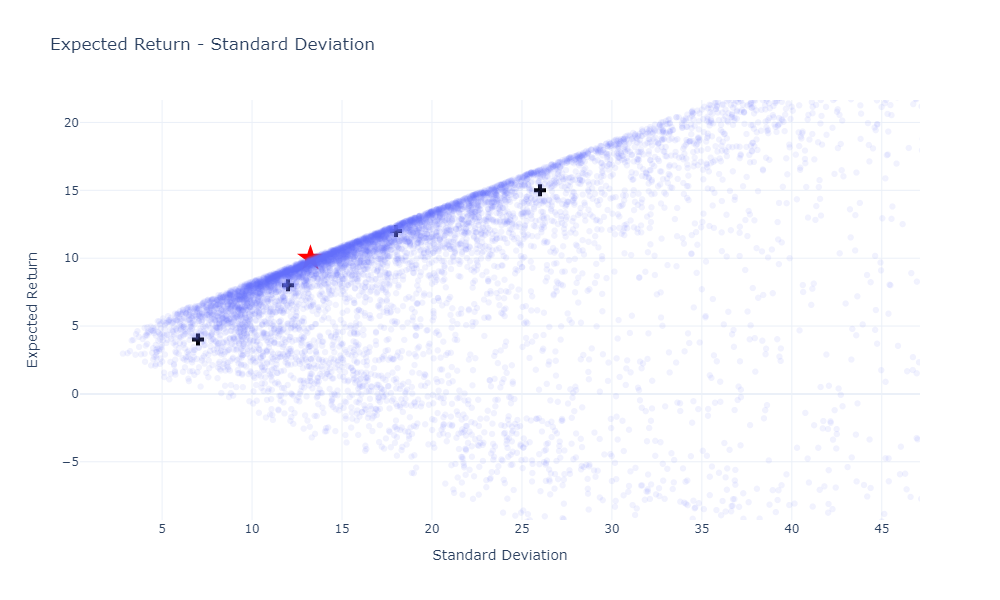

### Question 3

**Corresponding code in WANG_CODE.ipynb B.3**

- **Explain in plain English what this optimization does:**

Given a portfolio composed of Asset A, Asset B, Asset C and Asset D only ($\pmb{\omega^T}\pmb{1} = 1$). The optimization is to find the weights of the assets in a portfolio which has the least variance/risk possible.

- **Solve this optimization using the Lagrangian method:**

Recall the results from above:

$$ \pmb{\omega^*} = \pmb{\Sigma^{-1}}(\lambda\pmb{\mu} + \gamma\pmb{1}) $$$$ \lambda = \frac{Am-B}{AC-B^2} $$$$ \gamma = \frac{C-Bm}{AC-B^2} $$$$ \left\{ \begin{matrix} A = \pmb{1}^T\pmb{\Sigma^{-1}}\pmb{1} \\ B = \pmb{\mu}^T\pmb{\Sigma^{-1}}\pmb{1}\\ C = \pmb{\mu}^T\pmb{\Sigma^{-1}}\pmb{\mu} \end{matrix} \right. $$

In this case, there is only one constraint, which means $\gamma$ = 0, thus:

$$ \frac{C-Bm}{AC-B^2} = 0 $$

Take $C = Bm$ into $\lambda$:

$$ \begin{equation} \begin{aligned} \lambda &= \frac{Am-B}{AC-B^2}\\ &= \frac{Am-B}{ABm-B^2}\\ &= \frac{Am-B}{(Am-B)B}\\ &= \frac{1}{B} \end{aligned} \end{equation} $$

Take $\lambda$ and $\gamma$ into $\pmb{\omega^*}$:

$$ \begin{equation} \begin{aligned} \pmb{\omega^*} &= \pmb{\Sigma^{-1}}(\lambda\pmb{\mu} + \gamma\pmb{1})\\ &= \pmb{\Sigma^{-1}}\frac{\pmb{\mu}}{B}\\ &= \frac{\pmb{\Sigma^{-1}}\pmb{\mu}}{\pmb{\mu}^T\pmb{\Sigma^{-1}}\pmb{1}}\\ &= \frac{\pmb{\Sigma^{-1}}\pmb{1}}{\pmb{1}^T\pmb{\Sigma^{-1}}\pmb{1}}\\ &= \frac{\pmb{\Sigma^{-1}}\pmb{1}}{A} \end{aligned} \end{equation} $$

Taking the number into the calculation, the results are:

$$ \pmb{\omega^*} = \begin{pmatrix} 0.90541287\\ 0.82908361\\ -1.37463819\\ 0.64014171\\ \end{pmatrix} $$

- **Compute the return and standard deviation of this optimal portfolio:**

The return and standard deviation of a portfolio can be expressed as:

$$ \mu_{\pi} = \pmb{\omega^T}\pmb{\mu} $$$$ \sigma_{\pi} = \sqrt{\pmb{\omega^T}\pmb{\Sigma}\pmb{\omega}} $$

Substitute the $\pmb{\omega^*}$ and $\pmb{\Sigma}$ in, the result is $\mu_{\pi}$ = 0.03360788 and $\sigma_{\pi}$ = 0.02577473.

- **On a graph of expected returns plotted against standard deviation, identify and name this optimal portfolio:**

By reusing the plot before, the general description is the same. Additional, the green star represents the optimal portfolio with the minimum standard deviation/risk globally, which equals 0.02577473. The plot shows that there isn't any point which locate more left than the green star, which says the green star is the one with lowest standard deviation possible. This portfolio is named **The Global Minimum Variance Portfolio**.

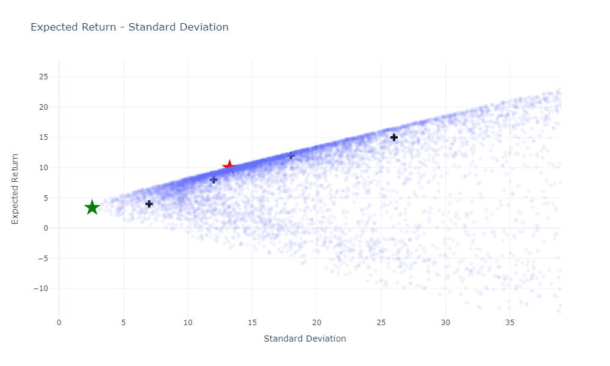

## C. Empirical Value at Risk

**The calculation results of Question 1 and Question 2 is saved in excel file "WANG_VaR.xlsx"**

### Question 1

**Corresponding code in WANG_CODE.ipynb C.1**

After loading the 'FTSE100.xlsx' file, first step is to calculate the returns. Notice that later on a 10-day VaR will be used for comparison (backtesting), so I calculated returns in logarithmic form in order to get a 10-day index return by the simple summation of the daily return:

$$ \begin{equation} \begin{aligned} u_{10D}^{(t)} &= ln(\frac{S_{t+10}}{S_t})\\ &= \sum_{i=0}^{9} ln(\frac{S_{t+i+1}}{S_{t+i}})\\ &= \sum_{i=0}^{9} u_{1D}^{(t)} \end{aligned} \end{equation} $$

where: $u_{10D}^{(t)}$ is the 10-day index return at the $t^{th}$ day which represents the total returns from the $t^{th}$ day to ${(t+10)}^{th}$ day, it will be used in the VaR backtesting later; $u_{1D}^{(t)}$ is the 1-day index return at the $t^{th}$ day; $S_t$ is the index price at the $t^{th}$ day. This 10-day index return is a future 10-day return which will be used for the backtesting of VaR.

The code for the return calculation is as below:

```
df['Returns'] = log(df['Closing Price']).diff().dropna()
```

And the returns is named as **Returns** in the dataframe.

Then calculate the 21-day sample standard deviation and 10-day index return (future) using

```
df['Standard Deviation'] = df['Returns'].rolling(window=21).std().dropna()
```

and

```
df['10D Returns'] = df['Returns'].rolling(window=10).sum().shift(-10).dropna()
```

which are named as **Standard Deviation** and **10D Returns** column respectively in the dataframe. Then project the standard deviation from 1-day to 10-day by the squart-root principle ($\sigma_{10D} = \sqrt{10}\sigma_{1D}$).

The mean for VaR calculation is regarded as constant and is the whole dataset mean scaled over 10-day, which is 0.386%. The 99%/10-day VaR is finally obtained in the column named **VaR_sample** by:

```
df['VaR_sample'] = norm.ppf(1-0.99, mu_10D, df['10D Standard Deviation'])
```

The VaR is given in return-percentage form.

### Question 2

**Corresponding code in WANG_CODE.ipynb C.2**

Now the volatilities are obtain by the GARCH(1,1) model with parameters of $\omega=0.000001$, $\alpha=0.047$ and $\beta=0.9466$. The initial variance for the model to start with is the sample variance for all returns, which is 0.00011759255521508201. The code of GARCH model is:

```
def garch(var0, ret):
    """
    var0  -float     the initial variance of the GARCH model
    ret   -Series    the realised returns
    """
    omega = 0.000001
    alpha = 0.047
    beta = 0.9466
    var = []
    for i in range(len(ret)):
        if i==0:
            var.append(nan)
        elif i==1:
            var.append(var0)
        else:
            var.append(omega + alpha * ret[i-1]**2 + beta * var[i-1])
    return array(var)
```

Notice that the first result is set to be nan because in the dataframe, the return column has the first value being 'NaN'. The result of this function is the variance, of which the square root is what to be used in the calculation of VaR. The volatility obtained by the GARCH model is named **GARCH vol** in the dataframe.

Applying the same time-scaling rule and VaR formula as before, the 99%/10-day VaR by using GARCH measure is obtained in the column named **VaR_Garch** by:

```
df['VaR_Garch'] = norm.ppf(1-0.99, mu_10D, df['10D GARCH vol'])
```

The VaR is given in return-percentage form.

### Question 3

**Corresponding code in WANG_CODE.ipynb C.3**

The number of breaches in the backtesting for the VaR with risk measure of sample standard deviation is 27. The eligible number of observation is 978. The percentage of VaR breaches for sample standard deviation measure is **2.7607361963190185%**.

The number of breaches in the backtesting for the VaR with risk measure of GARCH is 22. The eligible number of observation is 998. The percentage of VaR breaches for GARCH measure is **2.2044088176352705%**.

The two plots below shows the relationship between the realised 10-day index returns (orange line) and the 99%/10-day VaR (blue line) obtained by risk measures of sample standard deviation and GARCH respectively ($1^{st}$ plot is by using sample standard deviation, denoted as 'VaR_sample'; $2^{nd}$ plot is by using GARCH model, denoted as 'VaR_Garch') :

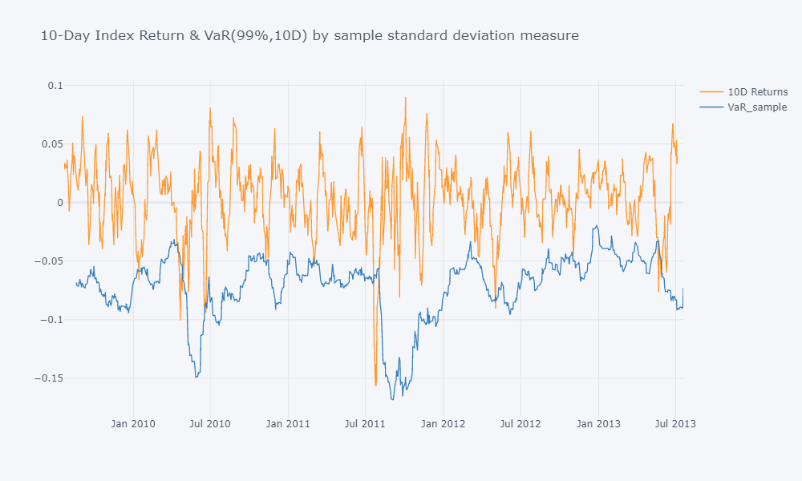

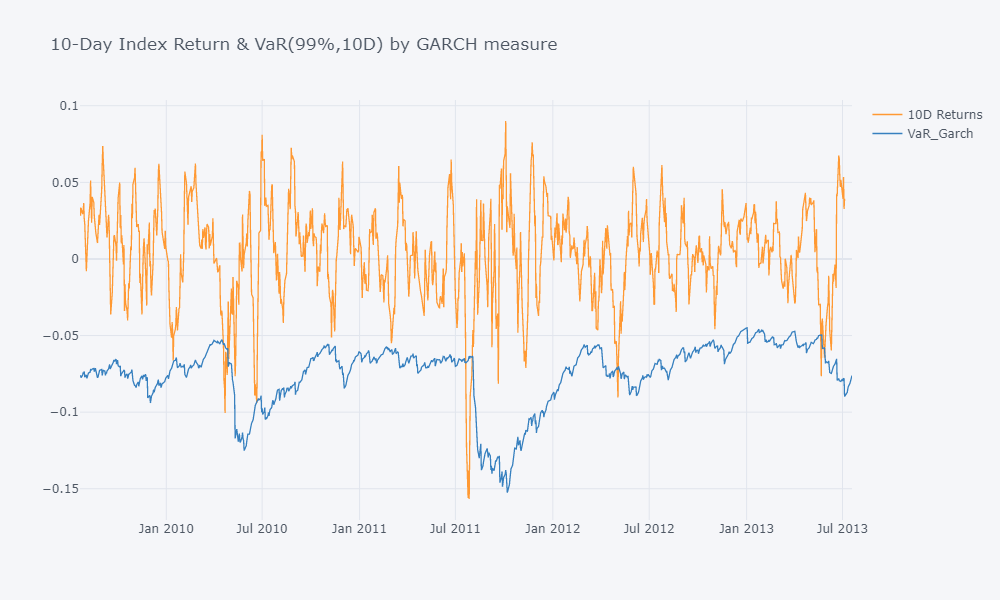

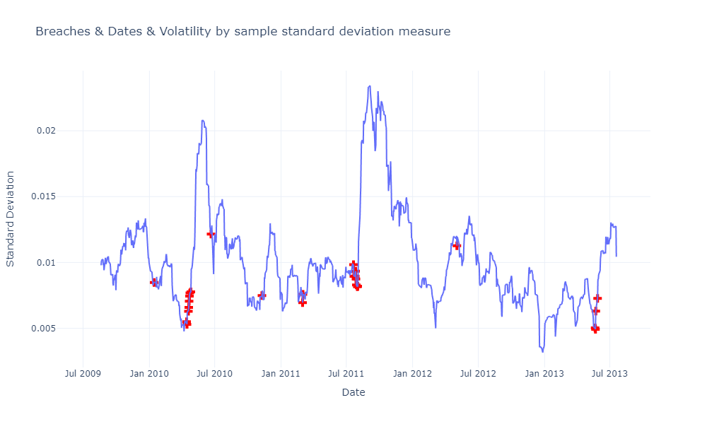

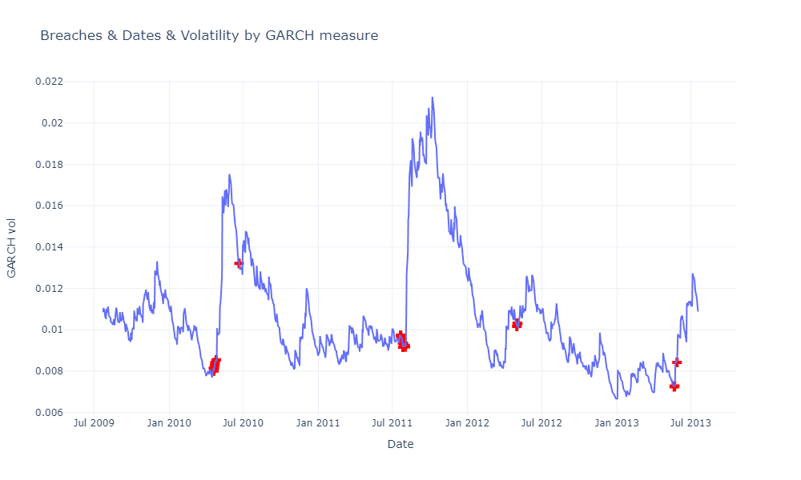

**A brief analysis of observation about the i.i.d for the breaches**

The backtesting compares the 10-day VaR with the realised index return of the future 10 days to test the risk control performance of the VaR. If the realised loss is bigger than the VaR forecast, it is regarded as a breach.

From the plots above, it's obvious to see the "clustering" phenomeno of the VaR breaches. The probabilities of breach for sample standard deviation measure and GARCH measure are 2.76% and 2.20% respectively. The number of consecutive breaches, which means a breach follows the other breach of the one previous time period, are 14 and 13 for each measure respectively. The conditional probabilities of the breach giving the occurrence of breach of the one previous day is $\frac{14}{27}$ and $\frac{13}{22}$ for each measure, result in 51.85% and 59.10% respectively which are much higher than the unconditional probabilities. **So the conclusion is that the VaR breach is not an i.i.d process.** It's strongly autocorrelated, so I would draw the conclusion of that **it is not time independent.**

According to the plots, almost all the breach points lie on the edges closed to the bottoms of the volatility curve (mostly for sample standard deviation measure) or just at the bottoms of the volatility curve. And this leads to a fact that most breaches happen when the volatility is relatively low. If the VaR breach is independent of the volatility, there is:

$$ P(AB) = P(A)P(B) $$

where $A$ represents the event of VaR breaches and $B$ represents the volatility range. Here, I introduce an index named $ratio$:

$$ \begin{equation} \begin{aligned} ratio &= \frac{P(AB)}{P(A)P(B)}\\ &= \frac{\frac{P(AB)}{P(B)}}{P(A)}\\ &= \frac{P(A|B)}{P(A)} \end{aligned} \end{equation} $$

where $P(A|B)$ is the conditional probability of VaR breaches given the condition of volatility. In the independent case, $ratio$ should be 1.

According to this dataset, the numbers of breaches happened with the volatility between 0.008 and 0.009 is 8 and 7 respectively for each measure; the percentage of breaches occured when the volatility is between 0.008 and 0.009 are $\frac{8}{27}$ and $\frac{7}{22}$, which are 29.63% and 31.82% for each measure. The probability of the volatility between 0.008 and 0.009 is $\frac{160}{978}$ = 16.36% for sample standard deviation measure, $\frac{188}{998}$ = 18.84% for GARCH measure. So the conditional probability is $\frac{8}{160}$ = 5% and $\frac{7}{188}$ = 3.72% respectively. The $ratio$s for each measure are $\frac{5}{2.76}$ = 1.81 and $\frac{3.72}{2.20}$ = 1.69 respectively.

By applying the same method to the other intervals of volatilities, the table below shows the results of sample standard deviation risk measure:

| Volatility Range (Sample STD) | Percentage of All Breaches | Probability of Volatility | Conditional Probability | ratio |
| --- | --- | --- | --- | --- |
| [0.003, 0.004) | 0.0% | 0.82% | 0.0% | 0.0 |
| [0.004, 0.005) | 3.7% | 0.51% | 20.0% | 7.24 |
| [0.005, 0.006) | 11.11% | 3.99% | 7.69% | 2.79 |
| [0.006, 0.007) | 14.81% | 8.38% | 4.88% | 1.77 |
| [0.007, 0.008) | 25.93% | 14.11% | 5.07% | 1.84 |
| [0.008, 0.009) | 29.63% | 16.36% | 5.0% | 1.81 |
| [0.009, 0.010) | 7.41% | 15.13% | 1.35% | 0.49 |
| [0.010, 0.011) | 0.0% | 10.12% | 0.0% | 0.0 |
| [0.011, 0.012) | 3.7% | 8.69% | 1.18% | 0.43 |
| [0.012, 0.013) | 3.7% | 7.67% | 1.33% | 0.48 |
| [0.013, 0.014) | 0.0% | 2.66% | 0.0% | 0.0 |
| [0.014, 0.015) | 0.0% | 3.78% | 0.0% | 0.0 |
| [0.015, 0.016) | 0.0% | 0.92% | 0.0% | 0.0 |
| [0.016, 0.017) | 0.0% | 0.2% | 0.0% | 0.0 |
| [0.017, 0.018) | 0.0% | 0.92% | 0.0% | 0.0 |
| [0.018, 0.019) | 0.0% | 0.92% | 0.0% | 0.0 |
| [0.019, 0.020) | 0.0% | 0.92% | 0.0% | 0.0 |

The the second table below show the results of GARCH risk measure:

| Volatility Range (GARCH) | Percentage of All Breaches | Probability of Volatility | Conditional Probability | ratio |
| --- | --- | --- | --- | --- |
| [0.007, 0.008) | 9.09% | 8.32% | 2.41% | 1.09 |
| [0.008, 0.009) | 31.82% | 18.84% | 3.72% | 1.69 |
| [0.009, 0.010) | 40.91% | 21.84% | 4.13% | 1.87 |
| [0.010, 0.011) | 13.64% | 19.34% | 1.55% | 0.71 |
| [0.011, 0.012) | 0.0% | 10.12% | 0.0% | 0.0 |
| [0.012, 0.013) | 0.0% | 5.61% | 0.0% | 0.0 |
| [0.013, 0.014) | 4.55% | 2.61% | 3.85% | 1.74 |
| [0.014, 0.015) | 0.0% | 2.81% | 0.0% | 0.0 |
| [0.015, 0.016) | 0.0% | 2.0% | 0.0% | 0.0 |
| [0.016, 0.017) | 0.0% | 2.2% | 0.0% | 0.0 |
| [0.017, 0.018) | 0.0% | 2.0% | 0.0% | 0.0 |
| [0.018, 0.019) | 0.0% | 1.6% | 0.0% | 0.0 |
| [0.019, 0.020) | 0.0% | 1.4% | 0.0% | 0.0 |

Accoring to the ratio information from the two tables above, I would say that **the VaR breaches are not independent of the level of the volatility/VaR**. It's more obvious to see in the results from sample standard deviation measure, as the $ratio$s are relatively further from 1, while in the results from GARCH measure this is not so obvious.